# BE/BAT 485/585

# Lab 5

## Exercise 1

In this exercise you will learn how to use a variety of radiation laws to compute:  
The Sun's Emissive power at the surface of the sun, at the top of the Erth's atmosphere, and any angle of incidence

[figure not shown]

## Theory

The sun is actually much hotter on the inside, but we can approximate its surface, *at which the emission takes place*, as a blackbody at a temperature of about **5780** $^o$K (numbers around **6000**$^o$K are used sometimes too).

## The Stefan-Boltzmann equation

This equation gives us the energy flux emitted at the sun’s surface:

### M$_s$ = σ.T$^4$ **[*Eq. 1*]**

Where:

> σ = 5.6697 × 10$^{-8}$ W·m$^{-2}$·K$^{-4}$, and  
> T = 5780$^o$K

# Inverse Square Distance Law

As this energy propagates through outerspace towards the Earth it weakens as it needs to cover much larger areas and volumes. It will spread over larger spherical surfaces as it travels outward. The intensity of this radiation decays proportionally to:

## $\frac{1}{r^2}$ **[*Eq. 2*]**

Where :

> r : is the distance away from the source.

[figure not shown]

# Cosine Law

### E<sub>θ</sub> = E. cos(θ) **[Eq. 3]**

[figure not shown]

With these three Equations, you can estimate the incident irradiance at any point in space at any angle.

# Derive the (model) Curve of the Cosine Law

```python
# load necessary library modules
import os
import sys
import numpy as np
import matplotlib.pyplot as plt
import math as math
```

```python
# Now create a figure of the Intensity following the cosine law

# Here we create a X-Axis from 0 to 90 degrees with 100 steps [array of x]. The linspace does that
x = np.linspace(0, 90, 100)

# conversion betwen degrees and degree Radians for all the whole array [x] created above
x_Rad=math.pi*x/180

# Cosine function again an array for all the numbers created above [x_Rad]
c = np.cos(x_Rad)
```

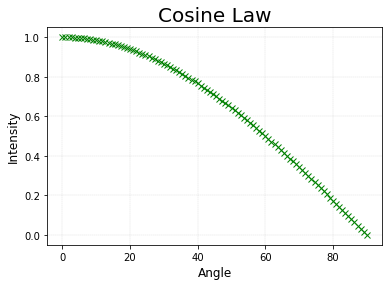

```python
#Study and undrstand this code so you can reuse it later

plt.plot(x, c, 'gx') # Plot the c vs x arrays [in degrees] using green color and 'x' markers [gx]. Try [ro]

# Add grids to plot
plt.grid(linestyle=':', linewidth='0.25', color='grey')

#Add titles to plot
plt.xlabel('Angle', fontsize=12)
plt.ylabel('Intensity', fontsize=12)
plt.title('Cosine Law', fontsize=20)

#plt.tight_layout()
#You can save your figure if you wish
plt.savefig('My_Cosine_Law_Plot.png')

# The above creates a canvas that need to be plotted now
plt.show()
```

```python
from scipy.constants import codata  # Sci-Python modules contain lots of physical and scientific constants so you do not need to recall them
# Access some physical constants and apply Planks Law
# https://www.nist.gov/programs-projects/codata-values-fundamental-physical-constants
# https://docs.scipy.org/doc/scipy-0.17.0/reference/constants.html
D = codata.physical_constants  # Where constants are stored

# to inspect what is in this databse of physcial constant use the print command
# print (D)
```

```python
#Stefan–Boltzmann constant
sigma=D['Stefan-Boltzmann constant'][0]
print ("The Stefan-Boltzmann constant = ",sigma)
```

```
The Stefan-Boltzmann constant =  5.670374419e-08
```

```python
# T_Sun temperature in Kelvin
T = 5780 # In degree Kelvin

# Sun Emmissivity
Ms = sigma * math.pow(T,4)

print("The sun's radiation @ Temperatue  = ",T, "K")
#print("Temperature = ",T, "K")
print("Emissive Power M (Watts/m^2)= ", Ms, "or = M (MW/m^2)",Ms/1E6)
```

```
The sun's radiation @ Temperatue  =  5780 K
Emissive Power M (Watts/m^2)=  63288250.47455248 or = M (MW/m^2) 63.288250474552484
```

```python
# Let us now use the databse of astrophysics constants
# From https://het.as.utexas.edu/HET/Software/Astropy-1.0/constants/index.html
from astropy import constants as const

Rs=const.R_sun
Re=const.R_earth

# Distance Sun to Earth 149597870700 m ~ 149.6E9
Dse=149.6E9

print ("The Sun Radius = ", Rs)
print ("The Earth Radius = ", Re)
print ("Sun Earth Distance = ", Dse)
```

```
The Sun Radius =    Name   = Nominal solar radius
  Value  = 695700000.0
  Uncertainty  = 0.0
  Unit  = m
  Reference = IAU 2015 Resolution B 3
The Earth Radius =    Name   = Nominal Earth equatorial radius
  Value  = 6378100.0
  Uncertainty  = 0.0
  Unit  = m
  Reference = IAU 2015 Resolution B 3
Sun Earth Distance =  149600000000.0
```

```python
# so at the Earth Surface the irradiance received is
I =  Ms * (Rs*Rs)/(Dse*Dse)

print("Irradiance at Earth Surface:")
print("Irradiance (W/m^2)=",I,"and in (J/s.m^2)=",I)
#print("Irradiance (J/s.m^2)=",I)
```

```
Irradiance at Earth Surface:
Irradiance (W/m^2)= 1368.6862678562256 m2 and in (J/s.m^2)= 1368.6862678562256 m2
```

# Homework - To do

```
* Please add new cells and code to find the irradiance received at a 30o  angle at the Equator
* Then at Boston
* Can you develop 2 curves that show how the Irradiance changes with Angle/Latitude?
```

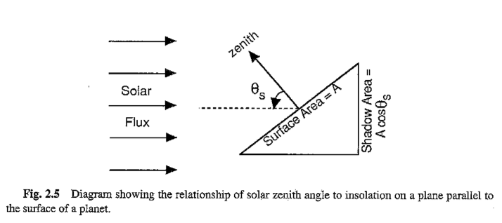

```python
from IPython.display import Image
Image('../Data/download.png')
```

```python
# your new code starts here
```

```python
I =  Ms * (Rs*Rs)/(Dse*Dse)

tilt = 23 #Earth's tilt, assuming
x = 30 + tilt # angle in question

# conversion between degrees and degree Radians for all the whole array [x] created above
x_rad=math.pi*x/180

print("Irradiance at 30 Degree Angle at the equator:")
print("Irradiance (W/m^2)=",I*np.cos(x_rad),"and in (J/s.m^2)=",I*np.cos(x_rad))
#print("Irradiance (J/s.m^2)=",I)

print()

# Now for Boston
lat = 42
x = lat + tilt
# conversion between degrees and degree Radians for all the whole array [x] created above
x_rad=math.pi*x/180

print("Irradiance at Boston, MA:")
print("Irradiance (W/m^2)=",I*np.cos(x_rad),"and in (J/s.m^2)=",I*np.cos(x_rad))
#print("Irradiance (J/s.m^2)=",I)
```

```
Irradiance at 30 Degree Angle at the equator:
Irradiance (W/m^2)= 823.6959579777852 m2 and in (J/s.m^2)= 823.6959579777852 m2

Irradiance at Boston, MA:
Irradiance (W/m^2)= 578.4318113897634 m2 and in (J/s.m^2)= 578.4318113897634 m2
```

```python
#display a message the program ended
print("program ended.")
```

```
program ended.
```

### Exercise 2

In this exercise, you will:

- read data from a BSQ file
- Extract and Slice this 3D DataCube, and extract
  1. Pixels from all bands
  2. Along a row (Horizontal slice)
  3. along a Columns (Vertical slice)
  4. Random lines (in any direction)
  5. Annotate the locations of these extracts

```python
# load library modules
import os
import numpy as np
import matplotlib.pyplot as plt

#Notice this is a new library with additonal functionality
# Can you follow prior instruction form prvious lab work and move the library
# to the lobrary folder and refer to it from there !?
import viplab_lib2 as vip  # This is an updated version of our library
```

```python
# Starts main program
#subset file information
filename="NEON_GreenValley.bsq"
nrows=500
ncols=500
nbands=426
datatype=np.int16
```

```python
# Read all bands into a single 3D DataCube

# Notice the -426  in the call and that means load all bands (all 426 of them)

DataCube=vip.BSQ_band_read(filename,-426,nrows,ncols)

# Assign some of the bands to band/color names that are easier to remember instaead of listing numbers
# Remember these could be from any neighboring bands also since this is hyperspectral
bandRED=48
bandGREEN=34
bandBLUE=17
bandNIR=97
bandSWIR1 = 4
bandSWIR2 = 5
```

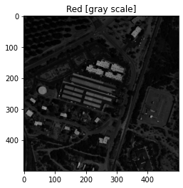

```python
#Display a single layer/band from the DataCube and Dislay as gray scale
plt.figure()
plt.title('Red [gray scale]')
plt.imshow(DataCube[:,:,bandRED],cmap='gray')
```

## Learn to manipulate the image display using statistcial information

```python
# So letsw get ssome info abotu the image
Num_Rows, Num_Col= np.shape(DataCube[:,:,bandRED])
print('Image width:  ', Num_Rows)
print('Image height: ', Num_Col)
print('Image Max Value: ', np.max(DataCube[:,:,bandRED]))
print('Image Min Value: ', np.min(DataCube[:,:,bandRED]))
print('Image Min Value: ', np.mean(DataCube[:,:,bandRED]))  # Notice the value versus Min and MAx
```

```
Image width:   500
Image height:  500
Image Max Value:  15307
Image Min Value:  0
Image Min Value:  1392.179816
```

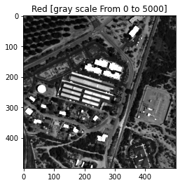

```python
#Using the info from above (min, max, avearge) we can manipulate the image display
# For example display a single layer/band from the DataCube as gray scale but stretched properly
# We do so by using the vmin and vmax parameters that basically force the image to display all data between those values

plt.figure()
plt.title('Red [gray scale From 0 to 5000]')
plt.imshow(DataCube[:,:,bandRED],cmap='gray', vmin=0,vmax=5000)
```